# AD2-Lab3-

```r
dadosTrain <- read_csv("data/train.csv")
dadosTest <- read_csv("data/test.csv")
dadosSample <- read_csv("data/sample_submission.csv")
View(dadosTest)
View(dadosTrain)
View(dadosSample)
```

1 Há desbalanceamento das classes (isto é, uma classe tem muito mais instâncias que outra)? Em que proporção? Quais efeitos colaterais o desbalanceamento de classes pode causar no classificador? Como você poderia tratar isso? (10 pt.)

```r
totalEleitos <- length(which(dadosTrain$situacao == "eleito"))
totalNaoEleitos <- length(which(dadosTrain$situacao == "nao_eleito"))
total <- totalEleitos + totalNaoEleitos

propEleitos = totalEleitos/total
propNaoEleitos = totalNaoEleitos/total

propEleitos
```

```
## [1] 0.1346103
```

```r
propNaoEleitos
```

```
## [1] 0.8653897
```

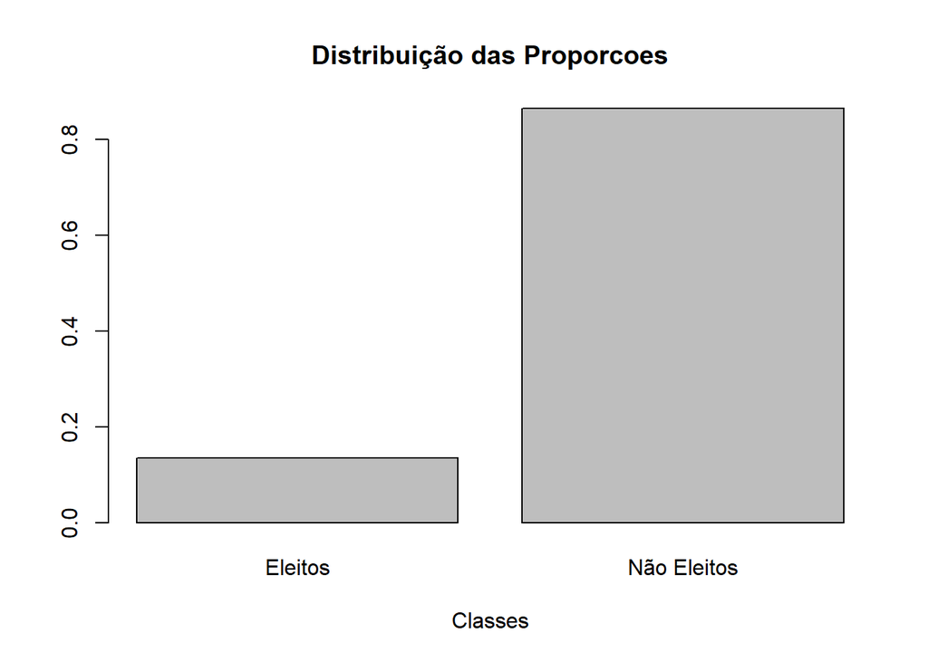

```r
proporcoes= c(propEleitos, propNaoEleitos)

barplot(proporcoes, main="Distribuição das Proporcoes",
        xlab="Classes",
        names.arg=c("Eleitos", "Não Eleitos"))
```

Há sim um desbalanciamento, sendo 13.4% de candidatos eleitos e 86.5% de candidatos não eleitos.

Grande parte dos algoritmos de classificação em Machine Learning são afetados por desbalanceamentos em classes preditoras. O principal efeito colateral causado por um desbalanceamento em um classificador é o seu enviesamento, tendo em vista que este irá inclinar-se a escolher a classe mais comum.

Tratamento dos dados:

```r
c1 = cor(dadosTrain$total_despesa, dadosTrain$quantidade_despesas)
c2 = cor(dadosTrain$quantidade_despesas, dadosTrain$media_despesa)
c3 = cor(dadosTrain$quantidade_doacoes, dadosTrain$quantidade_doadores)
c4 = cor(dadosTrain$quantidade_despesas, dadosTrain$quantidade_fornecedores)
c5 = cor(dadosTrain$total_despesa, dadosTrain$total_receita)
c1
```

```
## [1] 0.7405042
```

```r
c2
```

```
## [1] -0.007999216
```

```r
c3
```

```
## [1] 0.99696
```

```r
c4
```

```
## [1] 0.9861028
```

```r
c5
```

```
## [1] 0.9886651
```

Como existe grande correlação entre algumas variáveis, o que pode levar a redudância, podemos desconsiderá-las no modelo.

```r
formula <- as.formula(situacao ~ uf + partido + quantidade_doacoes + total_despesa + sexo + grau )
```

2 Treine: um modelo de KNN, regressão logística, uma árvore de decisão e um modelo de adaboost. Tune esses modelos usando validação cruzada e controle overfitting se necessário, considerando as particularidades de cada modelo. (20 pts.)

Regressão Logística

```r
ctrl <- trainControl(method = "repeatedcv", number = 10, repeats = 3, sampling = "up")
logitModel <- caret::train(formula, data=dadosTrain, method="glm", family="binomial",
                 trControl = ctrl, tuneLength = 10)
```

[output not shown]

Arvore de decisão

```r
ctrl <- trainControl(method = "repeatedcv", number = 10, repeats = 3, sampling = "up")
set.seed(3333)
decisionTreeModel <- train(formula, data=dadosTrain, method = "rpart",
                   parms = list(split = "information"),
                   trControl=ctrl,
                   tuneLength = 10)
```

Adaboost

```r
control <- rpart.control(cp = -1, maxdepth = 14, maxcompete = 1, xval = 0)
adaboostModel <- ada(formula, data = dadosTrain, type = c("discrete", "real", "gentle"), control = control, iter = 70)
```

Regressão Logistica

```r
pred = predict(logitModel, newdata=dadosTrain)
#confMatrix <- confusionMatrix(data=pred, dadosTrain$situacao)

#acc  <- confMatrix$overall['Accuracy']
#rec  <- recall(confMatrix$table, relevant = "eleito")
#pre  <- precision(confMatrix$table, relevant = "eleito")
#fmes <- F_meas(confMatrix$table, relevant = "eleito")
```

Arvore Decisão

```r
pred = predict(decisionTreeModel, newdata=dadosTrain)
#confMatrix <- confusionMatrix(data=pred, pred)

#acc  <- confMatrix$overall['Accuracy']
#rec  <- recall(confMatrix$table, relevant = "eleito")
#pre  <- precision(confMatrix$table, relevant = "eleito")
#fmes <- F_meas(confMatrix$table, relevant = "eleito")

#print (confMatrix)
```

4Interprete as saídas dos modelos. Quais atributos parecem ser mais importantes de acordo com cada modelo? (20 pts.)

Regressão Logistica

```r
logitModel
```

```
## Generalized Linear Model
##
## 7622 samples
##    6 predictor
##    2 classes: 'eleito', 'nao_eleito'
##
## No pre-processing
## Resampling: Cross-Validated (10 fold, repeated 3 times)
## Summary of sample sizes: 6860, 6859, 6860, 6861, 6860, 6860, ...
## Addtional sampling using up-sampling
##
## Resampling results:
##
##   Accuracy   Kappa
##   0.9026509  0.6470414
```

```r
#save.model(logitModel, "logitModel")
write.csv(c(logitModel$coefficients), file="result.csv")
```

Arvore de Decisão

```r
decisionTreeModel
```

```
## CART
##
## 7622 samples
##    6 predictor
##    2 classes: 'eleito', 'nao_eleito'
##
## No pre-processing
## Resampling: Cross-Validated (10 fold, repeated 3 times)
## Summary of sample sizes: 6861, 6860, 6859, 6859, 6859, 6861, ...
## Addtional sampling using up-sampling
##
## Resampling results across tuning parameters:
##
##   cp           Accuracy   Kappa
##   0.001624431  0.8822298  0.6195802
##   0.001949318  0.8824920  0.6200446
##   0.002339181  0.8823168  0.6196845
##   0.002436647  0.8820545  0.6190527
##   0.002923977  0.8813987  0.6176983
##   0.003898635  0.8780325  0.6108450
##   0.006822612  0.8670988  0.5880265
##   0.011695906  0.8670988  0.5880265
##   0.051656920  0.8670988  0.5880265
##   0.293372320  0.8670988  0.5880265
##
## Accuracy was used to select the optimal model using the largest value.
## The final value used for the model was cp = 0.001949318.
```

Adaboost

```r
adaboostModel
```

```
## Call:
## ada(formula, data = dadosTrain, type = c("discrete", "real",
##     "gentle"), control = control, iter = 70)
##
## Loss: exponential Method: discrete   Iteration: 70
##
## Final Confusion Matrix for Data:
##             Final Prediction
## True value   eleito nao_eleito
##   eleito        962         64
##   nao_eleito     53       6543
##
## Train Error: 0.015
##
## Out-Of-Bag Error:  0.026  iteration= 69
##
## Additional Estimates of number of iterations:
##
## train.err1 train.kap1
##         69         69
```